# Coffee Shop Purchasing Association Analysis

BIT-446 Assignment(T6) | Summer 2025

Noah MacGillivray

2025-06-29

**Environment:** Ubuntu, VS Code

## Introduction

This program is designed to analyze the relationship of a customer’s age, timeline of being a customer and their estimated age to gain insight if these variables are correlated to purchasing coffee and a donut at the same time for future business insight.

Logistic regression classification is used in the project to analyze these variables and build a model to (hopefully) predict further purchasing decisions. The general flow of the program is as follows: read data in –> analyze raw metrics –> split the first data field (that has known outcomes) into training/testing fields –> train the logistic regression model –> test the model’s performance –> analyze the outcomes –> predict with new data where the outcomes are unknown.

## Required Packages

```r
# Load packages
library(readxl)
library(class)
library(caTools)
library(caret)
```

```r
library(ggplot2)
library(lattice)
library(metrica)
library(skimr)
library(knitr)
library(kableExtra)
library(fmsb)
library(car)
cat("All packages loaded successfully!\n")
```

```
## All packages loaded successfully!
```

## Data Import and Conversion

The coffee shop data file imported includes three different sheets including the training/testing data (“TrainTestData”), the new data for predictions (“NewData”), and a sheet related to the data information (“Info”). The three sheets are read, placed in a list and then distributed to three different data field variables. The target variable (“LatteDonut”) in the training/testing data is then converted to a factor type to allow other packages below to analyze the results. This was done before splitting to allow for further testing as needed.

```r
# Read in sheet names
sheet_names <- excel_sheets("BIT-446-RS-T6-Lattes1.xlsx")

# Print the sheet to understand file structure
print(sheet_names)
```

```
## [1] "TrainTestData" "NewData"       "Info"
```

```r
# Create list to hold the different sheets
all_sheets <- list()

for (sheet in sheet_names) {
    all_sheets[[sheet]] <- read_excel("BIT-446-RS-T6-Lattes1.xlsx", sheet = sheet) # nolint
}
# Variable to hold the training data
lattes <- all_sheets[[1]]

# Variable to hold the final predictions data
lattes_new <- all_sheets[[2]]

# Variable to hold the data sheets information
data_info <- all_sheets[[3]]

# Convert target variable to factor (only for the training data)
lattes$LatteDonut <- as.factor(lattes$LatteDonut)
lattes$LatteDonut <- relevel(lattes$LatteDonut, ref = "0")
```

## Raw Data Summary

Here we view the raw data to the three sheets read in, head and tail are displayed to ensure proper import, info sheet is displayed describing each row in the data fields, and prints out a basic summary.

```r
#Print the TrainTestData sheet
cat("TrainTestData Sheet\n")
```

```
## TrainTestData Sheet
```

```r
print(lattes)
```

```
## # A tibble: 550 × 5
##    Record   Age EstMonthsCustomer EstSalary LatteDonut
##     <dbl> <dbl>             <dbl>     <dbl> <fct>
##  1      1    26                 7     46502 0
##  2      2    58                17     92946 1
##  3      3    36                 1     59027 1
##  4      4    66                18     92321 1
##  5      5    59                18     97795 1
##  6      6    31                 7     47402 0
##  7      7    35                 4     59692 0
##  8      8    62                20     98150 1
##  9      9    59                18     92634 1
## 10     10    32                 6     45902 0
## # ℹ 540 more rows
```

```r
# Print NewData sheet
cat("NewData Sheet\n")
```

```
## NewData Sheet
```

```r
print(lattes_new)
```

```
## # A tibble: 100 × 4
##    Record   Age EstMonthsCustomer EstSalary
##     <dbl> <dbl>             <dbl>     <dbl>
##  1      1    26                11     68523
##  2      2    58                23     52331
##  3      3    33                22     88986
##  4      4    34                 3     57489
##  5      5    35                10     82224
##  6      6    43                17     51234
##  7      7    24                11     86911
##  8      8    63                12     46947
##  9      9    68                11     68808
## 10     10    28                10     61485
## # ℹ 90 more rows
```

```r
# Print data info via kableExtra package
kable(data_info,
      caption = "Data Info",
      col.names = c("Variable", "Definition")) %>%
  kable_styling(bootstrap_options = c("striped", "hover", "condensed"),
                full_width = FALSE)
```

Data Info

| Variable | Definition |
| --- | --- |
| Record | record number (i.e., index field) |
| Age | estimated age of customer, in years; this is an input variable (i.e., feature) for the model |
| EstMonthsCustomer | estimated months the customer has frequented the coffee shop; this is an input variable (i.e., feature) for the model |
| EstSalary | estimated annual salary of the customer, in dollars; this is an input variable (i.e., feature) for the model |
| LatteDonut | 0 = coffee and donut not purchased simultaneously; 1 = coffee and donut purchased simultaneously; this is the target variable for the model |

```r
# Loops through all sheets imported and prints the tails
for (x in sheet_names) {
  cat("Sheet:", x, "\n")
  print(tail(all_sheets[[x]]))
  cat("\n")
}
```

```
## Sheet: TrainTestData
## # A tibble: 6 × 5
##   Record   Age EstMonthsCustomer EstSalary LatteDonut
##    <dbl> <dbl>             <dbl>     <dbl>      <dbl>
## 1    545    22                 6     41704          0
## 2    546    26                 9     45688          0
## 3    547    29                 1     43928          0
## 4    548    29                 9     43940          0
## 5    549    26                 1     49093          0
## 6    550    67                21     92224          1
##
## Sheet: NewData
## # A tibble: 6 × 4
##   Record   Age EstMonthsCustomer EstSalary
##    <dbl> <dbl>             <dbl>     <dbl>
## 1     95    65                 2     72397
## 2     96    48                16     96229
## 3     97    53                14     59264
## 4     98    63                 7     55633
## 5     99    52                20     74202
## 6    100    33                11     97951
##
## Sheet: Info
## # A tibble: 5 × 2
##   Variable          Definition
##   <chr>             <chr>
## 1 Record            record number (i.e., index field)
## 2 Age               estimated age of customer, in years; this is an input varia…
## 3 EstMonthsCustomer estimated months the customer has frequented the coffee sho…
## 4 EstSalary         estimated annual salary of the customer, in dollars; this i…
## 5 LatteDonut        0 = coffee and donut not purchased simultaneously; 1 = coff…
```

```r
# Loops through the first two sheets and prints the Skim summary
for (x in sheet_names[-length(sheet_names)]) {
  cat("=== Skim Summary for Sheet:", x, "===\n")
  print(skim(all_sheets[[x]]))
  cat("\n")
}
```

```
## === Skim Summary for Sheet: TrainTestData ===
## ── Data Summary ────────────────────────
##                            Values
## Name                       all_sheets[[x]]
## Number of rows             550
## Number of columns          5
## _______________________
## Column type frequency:
##   numeric                  5
## ________________________
## Group variables            None
##
## ── Variable type: numeric ──────────────────────────────────────────────────────
##   skim_variable     n_missing complete_rate      mean        sd    p0    p25
## 1 Record                    0             1   276.      159.        1   138.
## 2 Age                       0             1    39.4      16.2      18    26
## 3 EstMonthsCustomer         0             1     8.85      7.18      1     3
## 4 EstSalary                 0             1 62466.    20892.    40033 45892.
## 5 LatteDonut                0             1     0.322     0.468     0     0
##       p50    p75  p100 hist
## 1   276.    413.   550 ▇▇▇▇▇
## 2    33      56     70 ▇▆▃▂▅
## 3     6.5    16     26 ▇▃▁▂▁
## 4 52798   91350  98899 ▇▃▁▁▅
## 5     0       1      1 ▇▁▁▁▃
##
## === Skim Summary for Sheet: NewData ===
## ── Data Summary ────────────────────────
##                            Values
## Name                       all_sheets[[x]]
## Number of rows             100
## Number of columns          4
## _______________________
## Column type frequency:
##   numeric                  4
## ________________________
## Group variables            None
##
## ── Variable type: numeric ──────────────────────────────────────────────────────
##   skim_variable     n_missing complete_rate    mean       sd    p0     p25
## 1 Record                    0             1    50.5    29.0      1    25.8
## 2 Age                       0             1    46.3    13.8     21    35
## 3 EstMonthsCustomer         0             1    13.8     5.99     2    10
## 4 EstSalary                 0             1 70893.  16468.   40409 55653.
##       p50     p75  p100 hist
## 1    50.5    75.2   100 ▇▇▇▇▇
## 2    46.5    58      70 ▅▅▇▅▆
## 3    14      19      23 ▅▃▇▆▇
## 4 71990   86386   99266 ▅▇▅▆▆
```

## Data Splitting for *Stratified* Logistic Regression (LR) Training

```r
# Set seed for reproducible results
set.seed(3)

# Stratified random split 80/20
split <- sample.split(lattes$LatteDonut, SplitRatio = 0.8)

# Distribute the split data to training and testing
train_latte_donut <- subset(lattes, split == TRUE)
test_latte_donut <- subset(lattes, split == FALSE)

# Confirm the data was split correctly
print(train_latte_donut)
```

```
## # A tibble: 440 × 5
##    Record   Age EstMonthsCustomer EstSalary LatteDonut
##     <dbl> <dbl>             <dbl>     <dbl> <fct>
##  1      1    26                 7     46502 0
##  2      2    58                17     92946 1
##  3      3    36                 1     59027 1
##  4      7    35                 4     59692 0
##  5      8    62                20     98150 1
##  6      9    59                18     92634 1
##  7     10    32                 6     45902 0
##  8     11    31                 4     47634 0
##  9     12    31                 8     68884 1
## 10     13    59                21     91644 1
## # ℹ 430 more rows
```

```r
print(test_latte_donut)
```

```
## # A tibble: 110 × 5
##    Record   Age EstMonthsCustomer EstSalary LatteDonut
##     <dbl> <dbl>             <dbl>     <dbl> <fct>
##  1      4    66                18     92321 1
##  2      5    59                18     97795 1
##  3      6    31                 7     47402 0
##  4     28    19                 1     42473 0
##  5     29    28                 1     47200 0
##  6     34    67                16     95314 1
##  7     35    23                 5     49683 0
##  8     41    46                 6     66121 1
##  9     44    55                16     93957 1
## 10     51    20                 2     44795 0
## # ℹ 100 more rows
```

## Train Logistic Regression Classification Model

This is where we create the *logistic regression classification model* with:  
- **Features**: Age, EstMonthsCustomer, and EstSalary  
- **Target**: LatteDonut

```r
late_donut_lr_model <- glm(LatteDonut ~ Age + EstMonthsCustomer + EstSalary,
                           data = train_latte_donut,
                           family = binomial)
```

## Model Information and Summary

LR model summary is printed to show summary of model performance. Nagelkerke R^2 value is printed which shows the how well the model is segregating probabilities towards 0 or 1. Overall variable importance is printed to show how each variable is affecting the model.

```r
# View model summary
summary(late_donut_lr_model)
```

```
##
## Call:
## glm(formula = LatteDonut ~ Age + EstMonthsCustomer + EstSalary,
##     family = binomial, data = train_latte_donut)
##
## Coefficients:
##                     Estimate Std. Error z value Pr(>|z|)
## (Intercept)       -1.446e+01  2.220e+00  -6.513 7.38e-11 ***
## Age                7.019e-02  3.518e-02   1.995   0.0461 *
## EstMonthsCustomer  1.542e-01  8.171e-02   1.887   0.0592 .
## EstSalary          1.509e-04  3.623e-05   4.164 3.13e-05 ***
## ---
## Signif. codes:  0 '***' 0.001 '**' 0.01 '*' 0.05 '.' 0.1 ' ' 1
##
## (Dispersion parameter for binomial family taken to be 1)
##
##     Null deviance: 553.44  on 439  degrees of freedom
## Residual deviance: 117.83  on 436  degrees of freedom
## AIC: 125.83
##
## Number of Fisher Scoring iterations: 8
```

```r
# Calculate Nagelkerke R-squared value
nagelkerke_r2 <- NagelkerkeR2(late_donut_lr_model)
print(nagelkerke_r2)
```

```
## $N
## [1] 440
##
## $R2
## [1] 0.8780316
```

```r
# Calculate variable overall importance
var_importance <- varImp(late_donut_lr_model)
print(var_importance)
```

```
##                    Overall
## Age               1.994925
## EstMonthsCustomer 1.886751
## EstSalary         4.163827
```

## Exploration of Different Model Variables

```r
# Original model for comparison
cat("=======ALL THREE VARIABLES MODEL SUMMARY=======\n"); summary(late_donut_lr_model) # nolint
```

```
## =======ALL THREE VARIABLES MODEL SUMMARY=======
```

```
##
## Call:
## glm(formula = LatteDonut ~ Age + EstMonthsCustomer + EstSalary,
##     family = binomial, data = train_latte_donut)
##
## Coefficients:
##                     Estimate Std. Error z value Pr(>|z|)
## (Intercept)       -1.446e+01  2.220e+00  -6.513 7.38e-11 ***
## Age                7.019e-02  3.518e-02   1.995   0.0461 *
## EstMonthsCustomer  1.542e-01  8.171e-02   1.887   0.0592 .
## EstSalary          1.509e-04  3.623e-05   4.164 3.13e-05 ***
## ---
## Signif. codes:  0 '***' 0.001 '**' 0.01 '*' 0.05 '.' 0.1 ' ' 1
##
## (Dispersion parameter for binomial family taken to be 1)
##
##     Null deviance: 553.44  on 439  degrees of freedom
## Residual deviance: 117.83  on 436  degrees of freedom
## AIC: 125.83
##
## Number of Fisher Scoring iterations: 8
```

```r
# New model, remove age
model_no_age <- glm(LatteDonut ~ EstMonthsCustomer + EstSalary,
                    family = binomial, data = train_latte_donut)
cat("=======ESTMONTHSCUSTOMER+ESTSALARY MODEL SUMMARY=======\n"); summary(model_no_age) # nolint
```

```
## =======ESTMONTHSCUSTOMER+ESTSALARY MODEL SUMMARY=======
```

```
##
## Call:
## glm(formula = LatteDonut ~ EstMonthsCustomer + EstSalary, family = binomial,
##     data = train_latte_donut)
##
## Coefficients:
##                     Estimate Std. Error z value Pr(>|z|)
## (Intercept)       -1.367e+01  1.898e+00  -7.203 5.90e-13 ***
## EstMonthsCustomer  1.516e-01  7.871e-02   1.926   0.0541 .
## EstSalary          1.834e-04  3.047e-05   6.019 1.76e-09 ***
## ---
## Signif. codes:  0 '***' 0.001 '**' 0.01 '*' 0.05 '.' 0.1 ' ' 1
##
## (Dispersion parameter for binomial family taken to be 1)
##
##     Null deviance: 553.44  on 439  degrees of freedom
## Residual deviance: 121.92  on 437  degrees of freedom
## AIC: 127.92
##
## Number of Fisher Scoring iterations: 8
```

```r
# Remove EstMonthsCustomer
model_no_months <- glm(LatteDonut ~ Age + EstSalary,
                       family = binomial, data = train_latte_donut)
cat("=======AGE+ESTSALARY MODEL SUMMARY=======\n"); summary(model_no_months) # nolint
```

```
## =======AGE+ESTSALARY MODEL SUMMARY=======
```

```
##
## Call:
## glm(formula = LatteDonut ~ Age + EstSalary, family = binomial,
##     data = train_latte_donut)
##
## Coefficients:
##               Estimate Std. Error z value Pr(>|z|)
## (Intercept) -1.444e+01  1.845e+00  -7.828 4.97e-15 ***
## Age          7.032e-02  3.433e-02   2.048   0.0405 *
## EstSalary    1.646e-04  3.197e-05   5.148 2.63e-07 ***
## ---
## Signif. codes:  0 '***' 0.001 '**' 0.01 '*' 0.05 '.' 0.1 ' ' 1
##
## (Dispersion parameter for binomial family taken to be 1)
##
##     Null deviance: 553.44  on 439  degrees of freedom
## Residual deviance: 121.80  on 437  degrees of freedom
## AIC: 127.8
##
## Number of Fisher Scoring iterations: 7
```

```r
# Remove EstSalary
model_no_salary <- glm(LatteDonut ~ Age + EstMonthsCustomer,
                       family = binomial, data = train_latte_donut)
cat("=======AGE+ESTMONTHSCUSTOMER MODEL SUMMARY=======\n"); summary(model_no_salary) # nolint
```

```
## =======AGE+ESTMONTHSCUSTOMER MODEL SUMMARY=======
```

```
##
## Call:
## glm(formula = LatteDonut ~ Age + EstMonthsCustomer, family = binomial,
##     data = train_latte_donut)
##
## Coefficients:
##                   Estimate Std. Error z value Pr(>|z|)
## (Intercept)       -9.60182    1.11576  -8.606  < 2e-16 ***
## Age                0.15665    0.02689   5.826 5.67e-09 ***
## EstMonthsCustomer  0.24641    0.06018   4.095 4.23e-05 ***
## ---
## Signif. codes:  0 '***' 0.001 '**' 0.01 '*' 0.05 '.' 0.1 ' ' 1
##
## (Dispersion parameter for binomial family taken to be 1)
##
##     Null deviance: 553.44  on 439  degrees of freedom
## Residual deviance: 138.42  on 437  degrees of freedom
## AIC: 144.42
##
## Number of Fisher Scoring iterations: 7
```

```r
# EstSalary only model
model_salary_only <- glm(LatteDonut ~ EstSalary,
                        family = binomial, data = train_latte_donut)
cat("=======ESTSALARY ONLY MODEL SUMMARY=======\n"); summary(model_salary_only) # nolint
```

```
## =======ESTSALARY ONLY MODEL SUMMARY=======
```

```
##
## Call:
## glm(formula = LatteDonut ~ EstSalary, family = binomial, data = train_latte_donut)
##
## Coefficients:
##               Estimate Std. Error z value Pr(>|z|)
## (Intercept) -1.389e+01  1.602e+00  -8.671  < 2e-16 ***
## EstSalary    2.012e-04  2.532e-05   7.943 1.97e-15 ***
## ---
## Signif. codes:  0 '***' 0.001 '**' 0.01 '*' 0.05 '.' 0.1 ' ' 1
##
## (Dispersion parameter for binomial family taken to be 1)
##
##     Null deviance: 553.44  on 439  degrees of freedom
## Residual deviance: 126.13  on 438  degrees of freedom
## AIC: 130.13
##
## Number of Fisher Scoring iterations: 7
```

```r
# All three variables variable importance
cat("All three variables importance:\n"); var_importance
```

```
## All three variables importance:
```

```
##                    Overall
## Age               1.994925
## EstMonthsCustomer 1.886751
## EstSalary         4.163827
```

```r
var_importance_no_months <- varImp(model_no_months)
cat("Age+EstSalary Variable importance:\n"); var_importance_no_months
```

```
## Age+EstSalary Variable importance:
```

```
##            Overall
## Age       2.048441
## EstSalary 5.148233
```

```r
# Compare Nagelkerke R-squared
nagelkerke_r2_original <- NagelkerkeR2(late_donut_lr_model)
nagelkerke_r2_no_months <- NagelkerkeR2(model_no_months)
nagelkerke_r2_salary_only <- NagelkerkeR2(model_salary_only)

cat("Nagelkerke R-squared--Original (3 variables):\n"); nagelkerke_r2_original
```

```
## Nagelkerke R-squared--Original (3 variables):
```

```
## $N
## [1] 440
##
## $R2
## [1] 0.8780316
```

```r
cat("Nagelkerke R-squared--Age + EstSalary only:\n"); nagelkerke_r2_no_months
```

```
## Nagelkerke R-squared--Age + EstSalary only:
```

```
## $N
## [1] 440
##
## $R2
## [1] 0.8733219
```

```r
cat("Nagelkerke R-squared--EstSalary only:\n"); nagelkerke_r2_salary_only
```

```
## Nagelkerke R-squared--EstSalary only:
```

```
## $N
## [1] 440
##
## $R2
## [1] 0.8681514
```

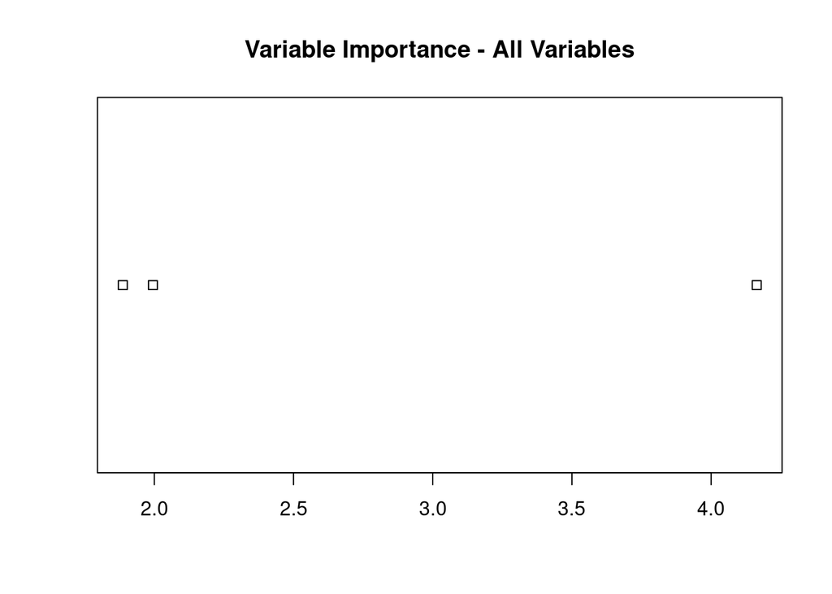

```r
# Plot the 3 vars and age+salary variable importance
plot(var_importance, main = "Variable Importance - All Variables")
```

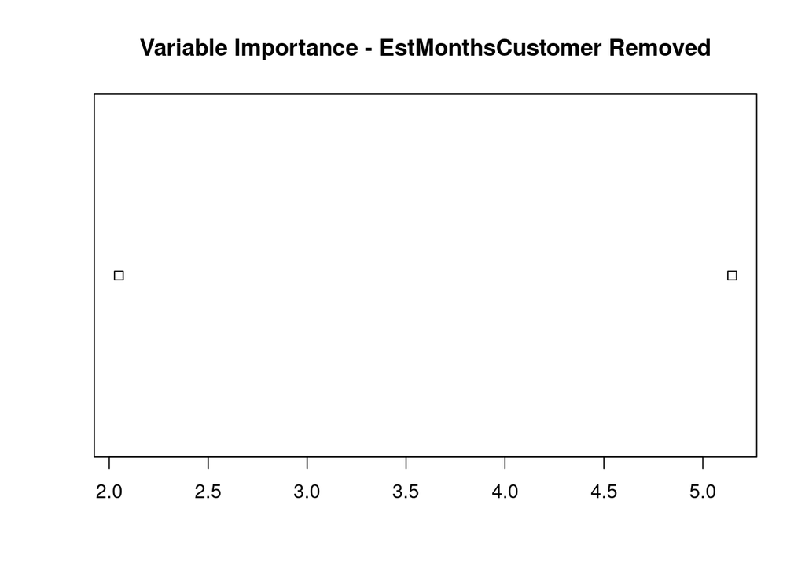

```r
plot(var_importance_no_months,
     main = "Variable Importance - EstMonthsCustomer Removed")
```

## Exploration of Variable Importance

Now that we have all of the metrics related to the LR model we can look at the variable importance and any corelation problems. To check these we look at corelation matrices, variance inflation factors, and the determinant of the correlation matrices.

```r
# Check correlations between predictors
cor_matrix_all_vars <- cor(lattes[, c("Age", "EstMonthsCustomer", "EstSalary")]) # nolint
print(cor_matrix_all_vars)
```

```
##                         Age EstMonthsCustomer EstSalary
## Age               1.0000000         0.8194954 0.9229264
## EstMonthsCustomer 0.8194954         1.0000000 0.8865444
## EstSalary         0.9229264         0.8865444 1.0000000
```

```r
cor_matrix_age_sal <- cor(lattes[, c("Age", "EstSalary")]) # nolint
print(cor_matrix_age_sal)
```

```
##                 Age EstSalary
## Age       1.0000000 0.9229264
## EstSalary 0.9229264 1.0000000
```

```r
cor_matrix_months_sal <- cor(lattes[, c("EstMonthsCustomer", "EstSalary")]) # nolint
print(cor_matrix_months_sal)
```

```
##                   EstMonthsCustomer EstSalary
## EstMonthsCustomer         1.0000000 0.8865444
## EstSalary                 0.8865444 1.0000000
```

```r
# Variance Inflation Factors (VIF)

vif(late_donut_lr_model)
```

```
##               Age EstMonthsCustomer         EstSalary
##          1.152303          1.003551          1.149028
```

```r
# Find determinant of correlation matrix
det_corr_all_vars <- det(cor_matrix_all_vars)
cat("Determinant of correlation matrix:", det_corr_all_vars, "\n")
```

```
## Determinant of correlation matrix: 0.0317204
```

```r
det_corr_age_sal <- det(cor_matrix_age_sal)
cat("Determinant of correlation matrix:", det_corr_age_sal, "\n")
```

```
## Determinant of correlation matrix: 0.1482068
```

```r
det_corr_months_sal <- det(cor_matrix_months_sal)
cat("Determinant of correlation matrix:", det_corr_months_sal, "\n")
```

```
## Determinant of correlation matrix: 0.214039
```

## Validate the Model (*all variables*)

At this point we have trained the LR model using the 80% training data from the split and now we want to make predictions based on the 20% split where we know the outcomes. We use the trained model (late_donut_lr_model), feed in the 20% split (test_latte_donut), and set the type to “response” to ensure we get probability values from 0 to 1. This is accomplished by using the inverse of the logit function where p = e^(logit) / (1 + e^(logit)). We then set the prediction threshold of 0.5 where values > 0.5 are classified at 1 and < 0.5 are 0. Those predictions are then converted to both a factor and then a single column vector.

**Note: Subsequent validations were completed after the initial validation to analyze other combinations of variables and noted below.**

```r
# Runs the LR model with predict () using the model we trained
raw_pred_all_vars <- predict(late_donut_lr_model,
                      newdata = test_latte_donut,
                      type = "response")

# Sets prediction threshold
raw_pred_all_vars <- ifelse(raw_pred_all_vars > 0.5, "1", "0")

# Convert to factor for comparison
raw_pred_all_vars <- as.factor(raw_pred_all_vars)
```

## Validate the Model (*EstMonthsCustomer removed*)

```r
# Runs the LR model with predict () using the model we trained
pred_simple_vars <- predict(model_no_months,
                            newdata = test_latte_donut,
                            type = "response")

# Sets prediction threshold
pred_simple_vars <- ifelse(pred_simple_vars > 0.5, "1", "0")

# Convert to factor for comparison
pred_simple_vars <- as.factor(pred_simple_vars)
```

## Validate the Model (*EstSalary only*)

```r
# Runs the LR model with predict () using the model we trained
pred_salary_only <- predict(model_salary_only,
                            newdata = test_latte_donut,
                            type = "response")

# Sets prediction threshold
pred_salary_only <- ifelse(pred_salary_only > 0.5, "1", "0")

# Convert to factor for comparison
pred_salary_only <- as.factor(pred_salary_only)
```

## Validate the Model (*EstMonthsCustomer + EstSalary only*)

```r
# Runs the LR model with predict() using the model we trained
pred_months_sal <- predict(model_no_age,
                          newdata = test_latte_donut,
                          type = "response")

# Sets prediction threshold
pred_months_sal <- ifelse(pred_months_sal > 0.5, "1", "0")

# Convert to factor for comparison
pred_months_sal <- as.factor(pred_months_sal)
```

## Model Results and Metrics

A confusion matrix and statistics, metrica metrics summary with it’s own confusion matrix were used for models including all the variables, ESTMONTHSCUSTOMER removed, AGE removed, and then ESTSALARY on its own.

```r
# Create confusion matrix for original df w/ all variables
conf_matrix_all_vars <-
  confusionMatrix(data = raw_pred_all_vars,
                  reference = test_latte_donut$LatteDonut,
                  mode = "prec_recall")

# Create confusion matrix for simple df w/ EstMonthsCustomer removed
conf_matrix_simple_vars <-
  confusionMatrix(data = pred_simple_vars,
                  reference = test_latte_donut$LatteDonut,
                  mode = "prec_recall")

# Create confusion matrix for salary only
conf_matrix_salary_only <-
  confusionMatrix(data = pred_salary_only,
                  reference = test_latte_donut$LatteDonut,
                  mode = "prec_recall")

# Create confusion matrix for months and salary
conf_matrix_months_salary <-
  confusionMatrix(data = pred_months_sal,
                  reference = test_latte_donut$LatteDonut,
                  mode = "prec_recall")

print(conf_matrix_all_vars)
```

```
## Confusion Matrix and Statistics
##
##           Reference
## Prediction  0  1
##          0 75  5
##          1  0 30
##
##                Accuracy : 0.9545
##                  95% CI : (0.8971, 0.9851)
##     No Information Rate : 0.6818
##     P-Value [Acc > NIR] : 1.519e-12
##
##                   Kappa : 0.8911
##
##  Mcnemar's Test P-Value : 0.07364
##
##               Precision : 0.9375
##                  Recall : 1.0000
##                      F1 : 0.9677
##              Prevalence : 0.6818
##          Detection Rate : 0.6818
##    Detection Prevalence : 0.7273
##       Balanced Accuracy : 0.9286
##
##        'Positive' Class : 0
##
```

```r
print(conf_matrix_simple_vars)
```

```
## Confusion Matrix and Statistics
##
##           Reference
## Prediction  0  1
##          0 75  5
##          1  0 30
##
##                Accuracy : 0.9545
##                  95% CI : (0.8971, 0.9851)
##     No Information Rate : 0.6818
##     P-Value [Acc > NIR] : 1.519e-12
##
##                   Kappa : 0.8911
##
##  Mcnemar's Test P-Value : 0.07364
##
##               Precision : 0.9375
##                  Recall : 1.0000
##                      F1 : 0.9677
##              Prevalence : 0.6818
##          Detection Rate : 0.6818
##    Detection Prevalence : 0.7273
##       Balanced Accuracy : 0.9286
##
##        'Positive' Class : 0
##
```

```r
print(conf_matrix_salary_only)
```

```
## Confusion Matrix and Statistics
##
##           Reference
## Prediction  0  1
##          0 75  5
##          1  0 30
##
##                Accuracy : 0.9545
##                  95% CI : (0.8971, 0.9851)
##     No Information Rate : 0.6818
##     P-Value [Acc > NIR] : 1.519e-12
##
##                   Kappa : 0.8911
##
##  Mcnemar's Test P-Value : 0.07364
##
##               Precision : 0.9375
##                  Recall : 1.0000
##                      F1 : 0.9677
##              Prevalence : 0.6818
##          Detection Rate : 0.6818
##    Detection Prevalence : 0.7273
##       Balanced Accuracy : 0.9286
##
##        'Positive' Class : 0
##
```

```r
print(conf_matrix_months_salary)
```

```
## Confusion Matrix and Statistics
##
##           Reference
## Prediction  0  1
##          0 74  6
##          1  1 29
##
##                Accuracy : 0.9364
##                  95% CI : (0.8733, 0.974)
##     No Information Rate : 0.6818
##     P-Value [Acc > NIR] : 9.02e-11
##
##                   Kappa : 0.8475
##
##  Mcnemar's Test P-Value : 0.1306
##
##               Precision : 0.9250
##                  Recall : 0.9867
##                      F1 : 0.9548
##              Prevalence : 0.6818
##          Detection Rate : 0.6727
##    Detection Prevalence : 0.7273
##       Balanced Accuracy : 0.9076
##
##        'Positive' Class : 0
##
```

```r
# ***All variables model***
# Converts factors back to numerical values and
# places them in a df to use w/ metric summary
obs_all_vars <- as.numeric(paste(test_latte_donut$LatteDonut))
pred_all_vars <- as.numeric(paste(raw_pred_all_vars))
data_all_vars <- data.frame(cbind(obs_all_vars, pred_all_vars))

# ***All variables model***
# Create comprehensive metrics summary using metrica package
metrics_summary(
  data = data_all_vars,
  obs = obs_all_vars,
  pred = pred_all_vars,
  pos_level = 1,
  type = "classification"
)
```

```
##         Metric      Score
## 1     accuracy 0.95454545
## 2   error_rate 0.04545455
## 3    precision 0.93750000
## 4       recall 1.00000000
## 5  specificity 0.85714286
## 6       balacc 0.92857143
## 7       fscore 0.96774194
## 8          agf 0.97724536
## 9        gmean 0.92582010
## 10        khat 0.89108911
## 11         mcc 0.89642146
## 12         fmi 0.96824584
## 13         bmi 0.85714286
## 14         csi 0.68181818
## 15      deltap 0.93750000
## 16       posLr 7.00000000
## 17       negLr 0.00000000
## 18         dor        Inf
## 19         npv 1.00000000
## 20         FPR 0.14285714
## 21         FNR 0.00000000
## 22         FDR 0.06250000
## 23         FOR 0.00000000
## 24      preval 0.68181818
## 25    preval_t 0.48074070
## 26     AUC_roc 0.64285714
## 27          p4 0.94488189
```

```r
# ***All variables model***
# Confusion matrix from metrica
confusion_matrix(
  data = data_all_vars,
  obs = obs_all_vars,
  pred = pred_all_vars,
)
```

```
##          OBSERVED
## PREDICTED  0  1
##         0 75  5
##         1  0 30
```

```r
# ***Age+Salary model***
# Converts factors back to numerical values and
# places them in a df to use w/ metric summary
obs_age_sal <- as.numeric(paste(test_latte_donut$LatteDonut))
pred_age_sal <- as.numeric(paste(pred_simple_vars))
data_age_sal <- data.frame(cbind(obs_age_sal, pred_age_sal))

# ***Age+Salary model***
# Create comprehensive metrics summary using metrica package
metrics_summary(
  data = data_age_sal,
  obs = obs_age_sal,
  pred = pred_age_sal,
  pos_level = 1,
  type = "classification"
)
```

```
##         Metric      Score
## 1     accuracy 0.95454545
## 2   error_rate 0.04545455
## 3    precision 0.93750000
## 4       recall 1.00000000
## 5  specificity 0.85714286
## 6       balacc 0.92857143
## 7       fscore 0.96774194
## 8          agf 0.97724536
## 9        gmean 0.92582010
## 10        khat 0.89108911
## 11         mcc 0.89642146
## 12         fmi 0.96824584
## 13         bmi 0.85714286
## 14         csi 0.68181818
## 15      deltap 0.93750000
## 16       posLr 7.00000000
## 17       negLr 0.00000000
## 18         dor        Inf
## 19         npv 1.00000000
## 20         FPR 0.14285714
## 21         FNR 0.00000000
## 22         FDR 0.06250000
## 23         FOR 0.00000000
## 24      preval 0.68181818
## 25    preval_t 0.48074070
## 26     AUC_roc 0.64285714
## 27          p4 0.94488189
```

```r
# ***Age+Salary model***
# Confusion matrix from metrica
confusion_matrix(
  data = data_all_vars,
  obs = obs_all_vars,
  pred = pred_all_vars,
)
```

```
##          OBSERVED
## PREDICTED  0  1
##         0 75  5
##         1  0 30
```

```r
# ***Salary only model***
# Converts factors back to numerical values and
# places them in a df to use w/ metric summary
obs_sal_only <- as.numeric(paste(test_latte_donut$LatteDonut))
pred_sal_only <- as.numeric(paste(pred_salary_only))
data_sal_only <- data.frame(cbind(obs_sal_only, pred_sal_only))

# ***Salary only model***
# Create comprehensive metrics summary using metrica package
metrics_summary(
  data = data_sal_only,
  obs = obs_sal_only,
  pred = pred_sal_only,
  pos_level = 1,
  type = "classification"
)
```

```
##         Metric      Score
## 1     accuracy 0.95454545
## 2   error_rate 0.04545455
## 3    precision 0.93750000
## 4       recall 1.00000000
## 5  specificity 0.85714286
## 6       balacc 0.92857143
## 7       fscore 0.96774194
## 8          agf 0.97724536
## 9        gmean 0.92582010
## 10        khat 0.89108911
## 11         mcc 0.89642146
## 12         fmi 0.96824584
## 13         bmi 0.85714286
## 14         csi 0.68181818
## 15      deltap 0.93750000
## 16       posLr 7.00000000
## 17       negLr 0.00000000
## 18         dor        Inf
## 19         npv 1.00000000
## 20         FPR 0.14285714
## 21         FNR 0.00000000
## 22         FDR 0.06250000
## 23         FOR 0.00000000
## 24      preval 0.68181818
## 25    preval_t 0.48074070
## 26     AUC_roc 0.64285714
## 27          p4 0.94488189
```

```r
# ***Salary only model***
# Confusion matrix from metrica
confusion_matrix(
  data = data_sal_only,
  obs = obs_sal_only,
  pred = pred_sal_only,
)
```

```
##          OBSERVED
## PREDICTED  0  1
##         0 75  5
##         1  0 30
```

```r
# ***Months+Salary model***
# Converts factors back to numerical values and
# places them in a df to use w/ metric summary
obs_months_sal <- as.numeric(paste(test_latte_donut$LatteDonut))
pred_months_sal <- as.numeric(paste(pred_months_sal))
data_months_sal <- data.frame(cbind(obs_months_sal, pred_months_sal))

# ***Months+Salary model***
# Create comprehensive metrics summary using metrica package
metrics_summary(
  data = data_months_sal,
  obs = obs_months_sal,
  pred = pred_months_sal,
  pos_level = 1,
  type = "classification"
)
```

```
##         Metric        Score
## 1     accuracy   0.93636364
## 2   error_rate   0.06363636
## 3    precision   0.92500000
## 4       recall   0.98666667
## 5  specificity   0.82857143
## 6       balacc   0.90761905
## 7       fscore   0.95483871
## 8          agf   0.95439293
## 9        gmean   0.90417023
## 10        khat   0.84752475
## 11         mcc   0.85259641
## 12         fmi   0.95533589
## 13         bmi   0.81523810
## 14         csi   0.67889908
## 15      deltap   0.89166667
## 16       posLr   5.75555556
## 17       negLr   0.01609195
## 18         dor 357.66666667
## 19         npv   0.96666667
## 20         FPR   0.17142857
## 21         FNR   0.01333333
## 22         FDR   0.07500000
## 23         FOR   0.03333333
## 24      preval   0.68181818
## 25    preval_t   0.47818521
## 26     AUC_roc   0.56934813
## 27          p4   0.92251478
```

```r
# ***Months+Salary model***
# Confusion matrix from metrica
confusion_matrix(
  data = data_months_sal,
  obs = obs_months_sal,
  pred = pred_months_sal,
)
```

```
##          OBSERVED
## PREDICTED  0  1
##         0 74  6
##         1  1 29
```

```r
print("Odds Ratios with 95% Confidence Intervals:")
```

```
## [1] "Odds Ratios with 95% Confidence Intervals:"
```

```r
exp(confint(model_no_months))
```

```
##                    2.5 %       97.5 %
## (Intercept) 6.815206e-09 1.100498e-05
## Age         1.004007e+00 1.150097e+00
## EstSalary   1.000107e+00 1.000233e+00
```

```r
# Point estimate for 5-year increase
age_5_year_odds_ratio <- exp(0.07032 * 5)
print(paste("5-year age increase OR:", age_5_year_odds_ratio))
```

```
## [1] "5-year age increase OR: 1.42133987404661"
```

```r
# Point estimate for $10,000 increase
salary_10k_odds_ratio <- exp(0.0001646 * 10000)
print(paste("$10,000 salary increase OR:", salary_10k_odds_ratio))
```

```
## [1] "$10,000 salary increase OR: 5.18619350822413"
```

## New Data LR Predictions

This chunk uses the model with with Age and EstSalary to make predictions on the new data. It adds two columns to the initial data field, prints and saves to CSV file for viewing.

```r
# Train new data without known predictions with months removed
coffee_donut_prediction <- predict(model_no_months,
                                   newdata = lattes_new,
                                   type = "response")

# Creates new column vector to hold the new probabilities
lattes_new$LR_prob <- coffee_donut_prediction
# Creates new column vector to hold the new predictions
lattes_new$LR_pred <- ifelse(coffee_donut_prediction > 0.5, 1, 0)

# Print df w/ prediction rows
print(lattes_new)
```

```
## # A tibble: 100 × 6
##    Record   Age EstMonthsCustomer EstSalary LR_prob LR_pred
##     <dbl> <dbl>             <dbl>     <dbl>   <dbl>   <dbl>
##  1      1    26                11     68523  0.209        0
##  2      2    58                23     52331  0.148        0
##  3      3    33                22     88986  0.926        1
##  4      4    34                 3     57489  0.0700       0
##  5      5    35                10     82224  0.826        1
##  6      6    43                17     51234  0.0482       0
##  7      7    24                11     86911  0.825        1
##  8      8    63                12     46947  0.0926       0
##  9      9    68                11     68808  0.841        1
## 10     10    28                10     61485  0.0870       0
## # ℹ 90 more rows
```

```r
# Export predictions added into the df
write.csv(lattes_new, file = "lattes_new_predictions.csv")
```

## Conclusion and Analysis

### Feature Variables

This was the most interesting part of the analysis to me. From the beginning, my intuition was that all the variables had some correlation, based off the fact that usually those with higher income are older, and if you are older you may have been going to the store as a regular for a while. This intuition is what made the coefficient signs make sense; if you have more money (with age usually) it would correlate positively with the purchasing behavior.

After I build the initial model and started to think more seriously about multicollinearity, the more complex the program became. I added in the correlation matrix and VIF score on the all variable model. The corelation matrix showed significant correlation between all variables, but the VIF score showed little. I researched more and it appears sometimes the VIF score is not a good indicator, and you may need to use other metrics. I added in the calculation of the determinant of the coefficient matrix which also showed heavy corelation, and disregarded the VIF score for the rest of the analysis.

After looking through all of the metrics for each model I concluded there is multicollinearity, and taking one of the two less powerful variables out of the model would be best. I contemplated using the single salary variable since it performed just as well at making predictions as the model with all variables or age+salary (95% accuracy), but found that the age variable still held statistical significance of (0.0405), and also had 95% accuracy. I believe by keeping this variable in we still have accurate predictions, it does offer some predictive power, and possibly more if the future data changes.

### Logistic Regression Equation

P(LatteDonut = 1) = e^(-14.44 + 0.07032×Age + 0.0001646×EstSalary) / (1 + e^(-14.44 + 0.07032×Age + 0.0001646×EstSalary))

### Odds Ratio

Looking at the odds ratio we calculated at the end of the program, we can expect every 5 years of age increase to correlate to about 1.42 times more likely for a customer to buy a coffee and donut, and an increase in $10K salary to correlate to about 5.2 times more likely for a customer to buy a coffee and donut.

### Most Important Feature Variable

As we can see from our metrics, the most important feature variable is EstSalary. When narrowing down the variables to 2 (age + salary) the overall variable importance showed Age of 2.048 and EstSalary 5.15. The statistical significance was also considerably higher in EstSalary with alpha = 2.63e-07 compared to Age with alpha = 0.0405.

### Predictive Power

Yes this model should be used to predict purchase of coffee and donut at the same time because the model correctly predicted 95% of the time and other metrics below.

### Confusion Matrix

- Correctly predicted 75 out of the customers who did not buy both, misclassified 5 as did not buy when they did (false negatives).
- Every time the model predicted buying both it was correct (precision).

### New Records Predictions

When new data was fed into the model it predicted simultaneous purchase of coffee and donut based on it’s probability. If it’s probability was predicted to be > 50% it classified it as a 1 (simultaneous buy) and if the probability was predicted to be < 50% it was 0 (did not buy simultaneously). The probabilities were based off of the logistic regression equation noted above where EstSalary had significantly more weight to the probability than age.